# Testing a Short-Term Trading Strategy Using a Rolling Window CAPM

Tan Zheng Liang

2022-11-29

## 1 Introduction

This project aims to test if the Capital Asset Pricing Model (CAPM) estimated using a rolling window could allow an investor or trader to take advantage of inefficiencies in market pricing. I used a short-term modeling strategy with 5 trading days of historical data per estimation to capture the short-term pricing inefficiencies. It does not conclude if the strategy is effective for all stocks, but applying the CAPM trading strategy on Apple Inc. was able to yield short-term outperformance. Furthermore, the stock had outperformed the S&P 500 ETF over the years but it could be attributed to having chosen a stock that had outperformed the market consistently.

## 2 Packages Required

```r
library(tidyquant) # Loads quantmod and PerformanceAnalytics packages
library(tidyverse) # Loads dplyr and ggplot2 packages (data manipulation and plotting)
```

## 3 Methodology and Data

There are 2 ways to estimate the beta of the stock. The first way is to regress the stock returns on the market returns to obtain the coefficient describing the relationship between these two variables, or the slope of the linear equation, which is the beta of the stock. The second way is to find the covariance of the market return and the stock return and divide it by the variance of the market return, which can be calculated simply by using **`PerformanceAnalytics::CAPM.beta()`**.

The steps to obtain a trading strategy based on the CAPM is as follows:

1. Estimate the beta using past 5 days of data
2. Estimate the required rate of return using the CAPM formula, where $R_M$ is the average daily log-return of the market index in the period used to estimate the beta and $R_f$ is the average daily return of the 1-month T-Bill
3. Estimate the expected rate of return, which is based on a naive method of using the average actual daily log-return of the stock during the estimation period
4. Compare the expected return to the required return

If expected return is more than required return, the stock is undervalued and I would take a long position on the stock on the next trading day at the opening price. If the expected return is less than the required return, the stock is overvalued and I would sell the long position (or take a short position for sophisticated traders) on the next trading day. I assumed that trading cost is 0 and that trades can be filled at any point in time. Furthermore, if expected return is negative, I would not take a long position as that means AAPL is on a short-term downtrend.

I used **`quantmod::getSymbols()`** to obtain historical prices of AAPL and SPY, which can also be used to obtain the market yield of the 1-month US T-Bill from the FRED database.

```r
# Set start and end date for data retrieval (does not work when retrieving data from FRED)
startdate <- as.Date("2017-12-31")
enddate <- as.Date("2022-11-01")

spy <- quantmod::getSymbols(Symbols = "SPY", src = "yahoo", auto.assign = FALSE,
                            from = startdate, to = enddate, periodicity = "daily")

aapl <- quantmod::getSymbols(Symbols = "AAPL", src = "yahoo", auto.assign = FALSE,
                            from = startdate, to = enddate, periodicity = "daily")
```

```r
# Retrieving data from FRED automatically retrieves the whole series available
US1M <- quantmod::getSymbols(Symbols = "DGS1MO", src = "FRED", auto.assign = FALSE)

rfr <- US1M["2017-12-31/2022-10-31"]
```

```r
# Merge adjusted closing prices (col. 6) of AAPL and SPY with risk-free rate
dat <- merge(aapl[,6], spy[,6], rfr, all = F)

# Rename columns
colnames(dat) <- c("AAPL", "SPY", "RFR")

# Check for missing data
colSums(is.na(dat))
```

```
## AAPL  SPY  RFR
##    0    0    9
```

```r
# Replace NA in rfr with last observation and convert to daily rate by dividing 252
dat$RFR <- na.locf(dat$RFR)/252

# Preview data
head(dat)
```

```
##                AAPL      SPY         RFR
## 2018-01-02 40.95049 247.8998 0.005119048
## 2018-01-03 40.94337 249.4678 0.005119048
## 2018-01-04 41.13354 250.5192 0.005079365
## 2018-01-05 41.60186 252.1887 0.005039683
## 2018-01-08 41.44734 252.6499 0.005158730
## 2018-01-09 41.44259 253.2218 0.005039683
```

```r
# Calculate log returns for AAPL and SPY using PerformanceAnalytics::Return.calculate()
# Convert returns to percentage
dat <- cbind(dat,
             PerformanceAnalytics::Return.calculate(prices = dat$AAPL, method = "log") * 100,
             PerformanceAnalytics::Return.calculate(prices = dat$SPY, method = "log") * 100) %>%
  `colnames<-`(c(colnames(dat), "rAAPL", "rSPY"))

head(dat)
```

```
##                AAPL      SPY         RFR       rAAPL      rSPY
## 2018-01-02 40.95049 247.8998 0.005119048          NA        NA
## 2018-01-03 40.94337 249.4678 0.005119048 -0.01739325 0.6305374
## 2018-01-04 41.13354 250.5192 0.005079365  0.46340523 0.4205680
## 2018-01-05 41.60186 252.1887 0.005039683  1.13209102 0.6642093
## 2018-01-08 41.44734 252.6499 0.005158730 -0.37211241 0.1827048
## 2018-01-09 41.44259 253.2218 0.005039683 -0.01145857 0.2261167
```

## 4 Estimating the Rolling-Window CAPM

The beta can be estimated with **`PerformanceAnalytics::CAPM.beta()`** and **`rollapply()`** using the past 5 observations. Proxy for the expected return can also be calculated with **`rollapply()`**.

```r
dat$beta <- rollapply(data = dat[-1, 4:5], width = 5, by.column = F,
                      function(x) CAPM.beta(Ra = x[,1], Rb = x[,2]))

dat$exp.return <- rollapply(data = dat[-1, 4], width = 5, mean)
```

Calculate the required return for AAPL based on CAPM each day, after obtaining the average market return and risk-free rate:

```r
dat$mean.RFR <- rollapply(data = dat[-1, 3], width = 5, mean)

dat$mean.RM <- rollapply(data = dat[-1, 5], width = 5, mean)

dat$req.return <- dat$mean.RFR + dat$beta * (dat$mean.RM - dat$mean.RFR)
```

## 5 Implementing the Trading Strategy

As mentioned in Section 3, if the expected return is higher than required return, I would long AAPL the next trading day at the opening price, and if it is lower, I would sell the long position at the opening price the next trading day.

This would be first denoted by “1” if the CAPM trading strategy indicated a long position, and “0” if a sell position (or can be viewed as no position in the stock).

```r
# Create a new xts object saving only the needed columns of data
dat2 <- na.omit(merge(dat[,c(7,10)], aapl$AAPL.Open))

# Use the Lag() function to shift the results down one row
dat2$signal <- Lag(dat2$exp.return > dat2$req.return & dat2$exp.return > 0)
```

Since I would buy and sell at the opening price, I would calculate the returns of the trading strategy using these prices for simplicity.

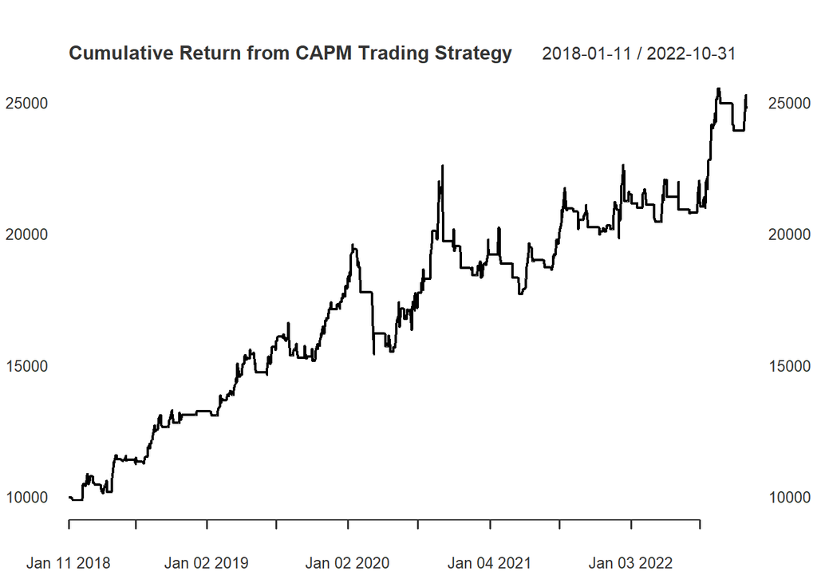

```r
# Signal created can be seen as the weight of the asset on a particular day
# Need to lag one more period as I assume a buy or sell on the next trading day opening price
trading_returns <- Return.calculate(prices = dat2$AAPL.Open, method = "log") * Lag(dat2$signal)

# Plot cumulative return from trading strategy by converting log returns to standard returns
# Assume starting capital of $10,000
plot(10000*(exp(cumsum(na.omit(trading_returns)))),
     main = "Cumulative Return from CAPM Trading Strategy",
     grid.col = NA)
```

## 6 Summary and Final Remarks

To summarize, I plotted the trading returns together with the actual returns from AAPL on a buy-and-hold strategy and the returns from investing in the S&P 500 ETF and obtained the annualized return and standard deviation to compare the performance of the trading strategy.

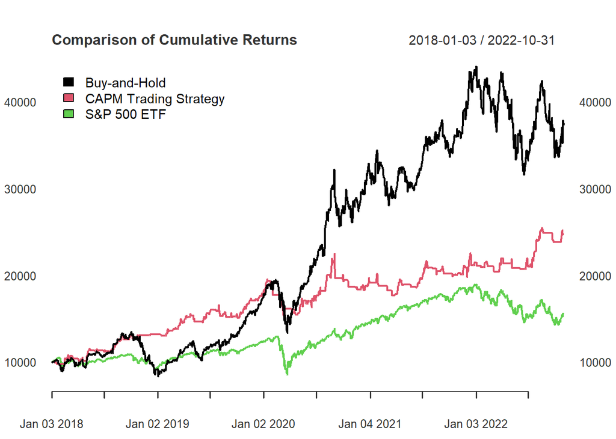

```r
return_plot <- merge(10000*(exp(cumsum(na.omit(dat$rAAPL/100)))),
           10000*(exp(cumsum(na.omit(trading_returns)))),
           10000*(exp(cumsum(na.omit(dat$rSPY/100)))))

colnames(return_plot) <- c("Buy-and-Hold", "CAPM Trading Strategy", "S&P 500 ETF")

plot(return_plot,
     main = "Comparison of Cumulative Returns",
     legend.loc = "topleft",
     grid.col = NA)
```

```r
return_dat <- merge(dat$rAAPL/100, trading_returns, dat$rSPY/100)

colnames(return_dat) <- c("Buy-and-Hold", "CAPM Trading Strategy", "S&P 500 ETF")

table.AnnualizedReturns(R = return_dat, scale = 252, geometric = FALSE)
```

|  | Buy-and-Hold | CAPM Trading Strategy | S&P 500 ETF |
| --- | --- | --- | --- |
| Annualized Return | 0.2733 | 0.1893 | 0.0919 |
| Annualized Std Dev | 0.3330 | 0.1805 | 0.2159 |
| Annualized Sharpe (Rf=0%) | 0.8206 | 1.0487 | 0.4256 |

In the short run, the CAPM trading strategy was able to outperform a buy-and-hold strategy. However, as expected, active trading did not outperform a more passive strategy. However, the CAPM strategy had a lower annualized standard deviation, resulting in a higher annualized Sharpe ratio. The strategy had also outperformed the SPY over the 5 year period.

There are 2 important caveats to the trading strategy proposed here:

1. As mentioned in Section 3, I assumed zero transaction costs and that trades can be filled at the opening price at any point in time
2. Only a single stock was chosen for the backtesting, which means that it may or may not apply to other stocks

In the future, I would test if the CAPM strategy could be improved, for example by changing the way the expected returns are estimated or by adding other factors to the model to improve the estimate of the required returns.